# Experimental Economics: Data Workflow

oTree: Online Deployment

Author

Matteo Ploner

Published

May 9, 2023

# 1 oTree: Online Deployment

## 1.1 From local to online

- When you test your software you deploy it locally with command

```bash
otree devserver
```

- To deploy it online we need to take the app to an oline *server*
- We can use the oTree hub or a cloud service
  - A possible cloud solution is [render.com](https://render.com/)
    - Free with limitations
    - Works with Github
  - In the past we used [Heroku](https://www.heroku.com/) but it is not free anymore

# 2 Github

## 2.1 Step 1: create a Github account

- Go to github.com and create an account
- Create a new repository

[figure not shown]

[figure not shown]

- Name it something like `otree-experiments`
  - Name is free

# 3 Render.com

## 3.1 Step 2: create a render.com account

- I signed in with my existing Github account

[figure not shown]

[figure not shown]

- Choose a free plan
  - *Individual* is free but limited

## 3.2 Step 3a: create a render.com web service

- Create a new web service

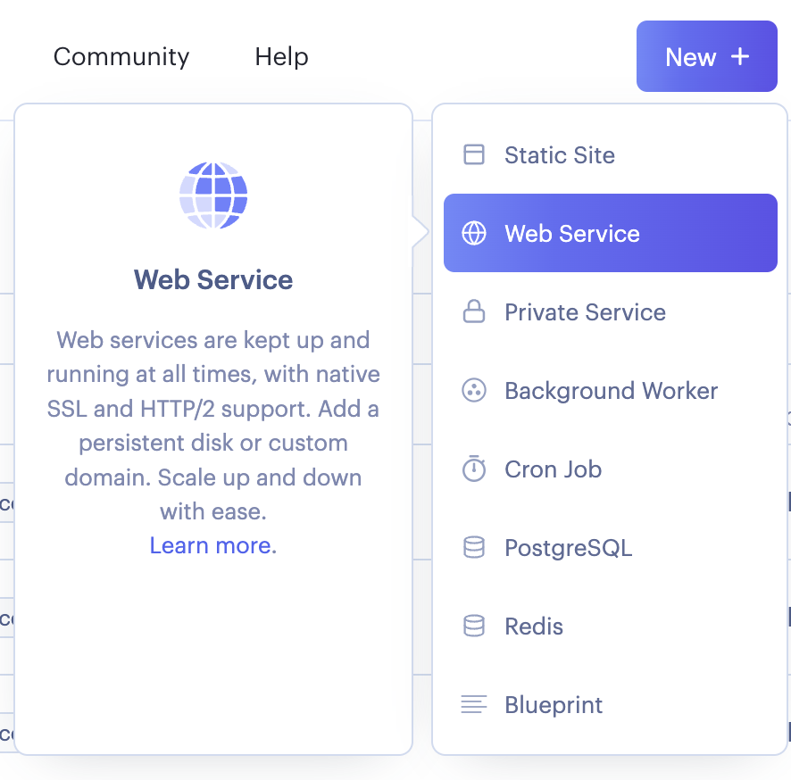

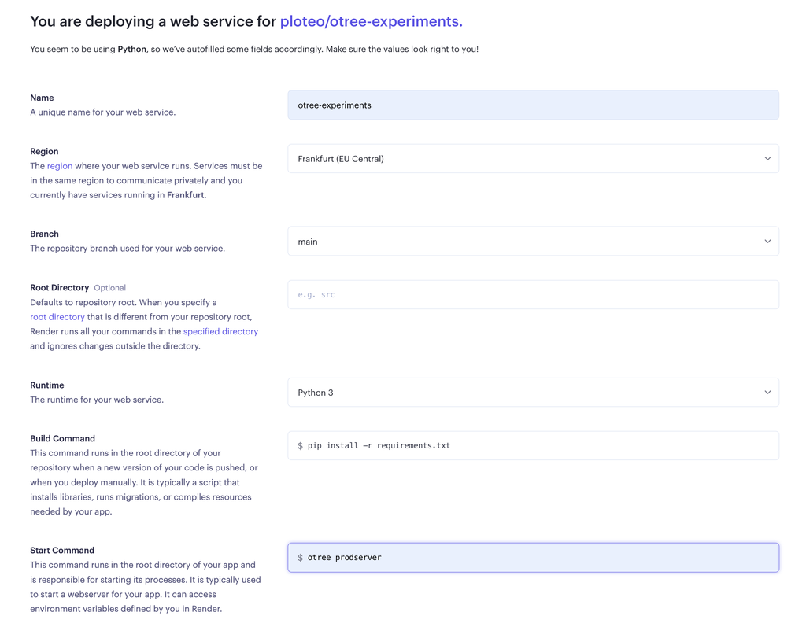

- Set properties like in the figure

## 3.3 Step 3b: create a render.com web service

- Setup environment variables

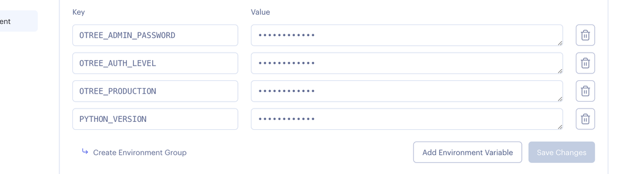

- Set properties like in the figure
  - OTREE_ADMIN_PASSWORD: [here your password]
  - OTREE_AUTH_LEVEL: STUDY
  - OTREE_PRODUCTION: 1
  - PYTHON_VERSION: 3.9.13

# 4 Github → Render.com

## 4.1 Step 4: upload your files to Github

- Upload your oTree repository to Github
  - App + settings.py +requirements.txt

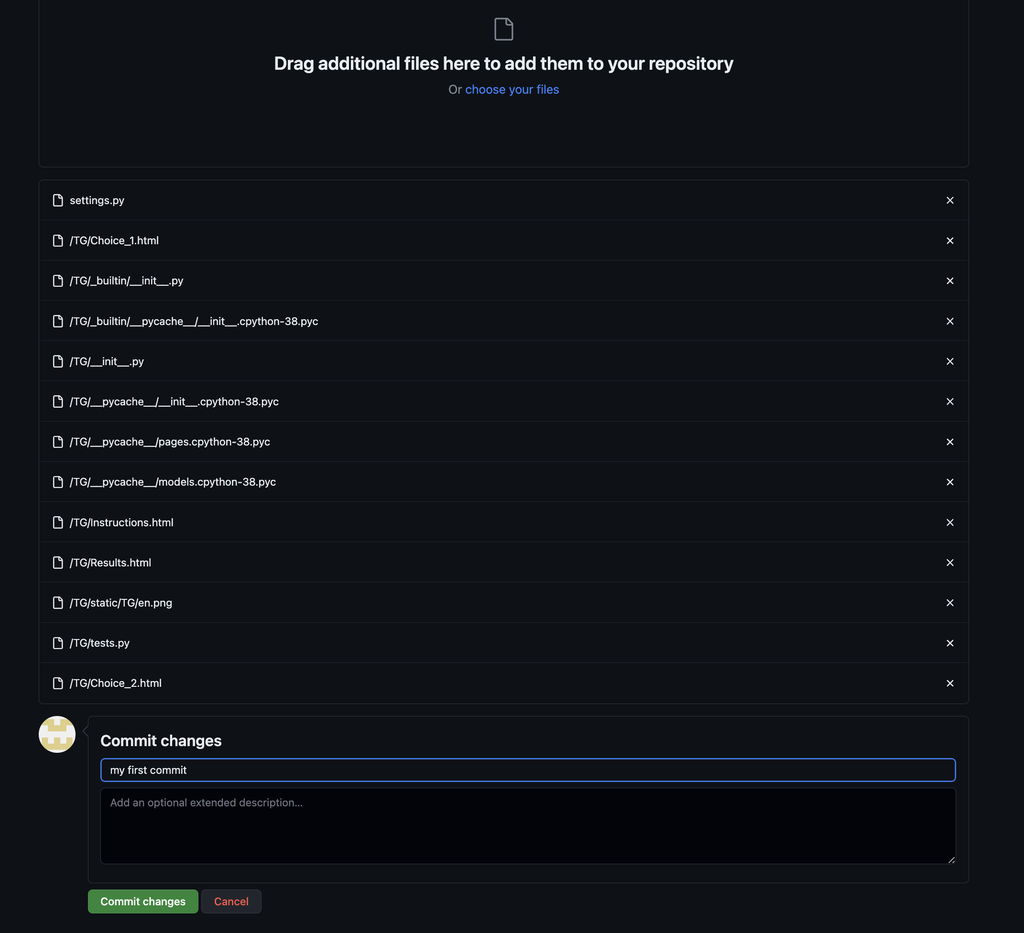

- Commit your changes
  - The process is smoother if you clone the repository on your computer
    - Better to use Gitub Desktop to manage the commits

## 4.2 Step 5: test your app

- If you go to the webpage

[figure not shown]

- You should see the app running

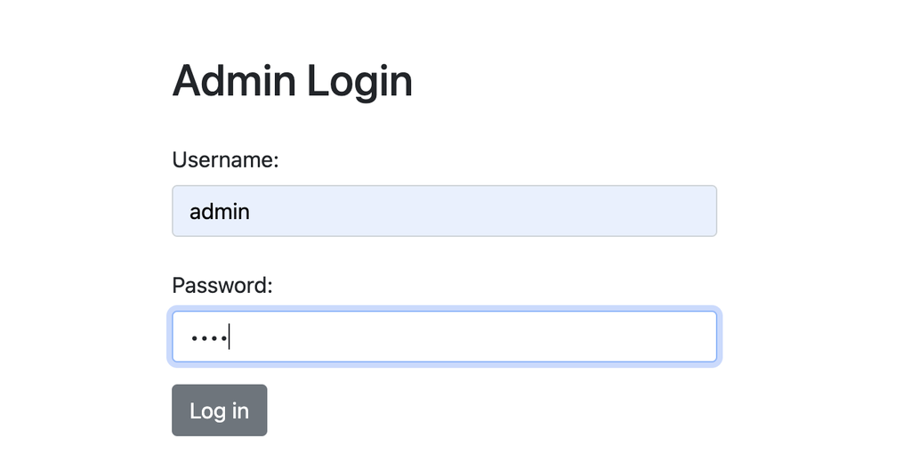

- Enter your admin password

## 4.3 Step 6: share the link on the Web

- Now you can create sessions

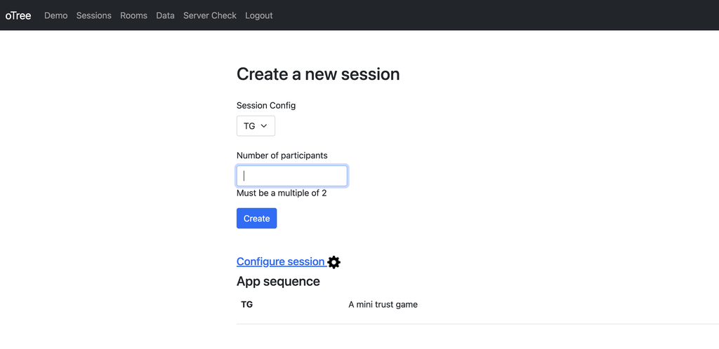

- Share the link with participants!

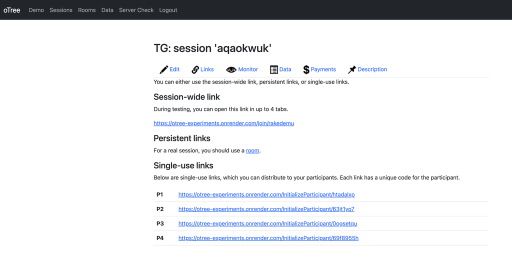

- You are ready to collect data!